# GLORIA second stage_Diversity and niche

## 前述

這是GLORIA第二階段發表的paper試驗 主軸在更細緻的討論樣區的物種多樣性在不同時期的變化以及消失、出現的物種特性。 研究問題： 1. 在各山峰細緻的生物多樣性表現出怎樣的格局?是否跟溫度或其他環境因子有關? 2. 在第一篇報告中，我們發現有溫度上升的事實。那增加的物種與覆蓋度擴大的物種是否與溫度上升有關?那消失的物種呢? ## 研究目的 1. 討論六座山峰中各方位樣區alpha多樣性與Beta多樣性 2. 六座山峰的多樣性變化趨勢與氣候變化趨勢 3. 討論消失與出現物種的氣候區位與生活型 4. 植群氣候區位組成是否反映了氣候變化型態

## 分析測試

### package 載入

分析使用到的package集中處

### 基礎資料載入

載入三項基礎資料，分別為2008-2020的section plot 調查資料、section plot 的環境資料以及日均溫與降雨量資料

[output not shown]

### Test 1

**核心概念(空間)** 在單一時間尺度下，以各山峰樣區為單位，他的Alpha 多樣性與Beta多樣性會是如何? #### 方法 試著使用單一維度(多樣性指數)與多維度(CA)的方式來探討 step 1. 基本資料處理

[output not shown]

Step 2. 處理氣候資料

| summit | direction | w_period | temp | temp_sd |
| --- | --- | --- | --- | --- |
| SUN | E | P2 | 11.306133 | 3.587909 |
| SUN | E | P3 | 11.393127 | 2.986156 |
| SUN | N | P2 | 8.996510 | 4.141503 |
| SUN | N | P3 | 9.085512 | 3.828900 |
| SUN | S | P2 | 11.832720 | 3.199445 |
| SUN | S | P3 | 11.990667 | 2.560284 |
| SUN | W | P2 | 8.937390 | 4.121872 |
| SUN | W | P3 | 8.920432 | 3.814033 |
| YAT | E | P2 | 9.789941 | 3.966816 |
| YAT | E | P3 | 9.812969 | 3.645265 |

[output cut: 38 more lines]

Step 4. 多變量分析 嘗試使用ca檢視植群組成

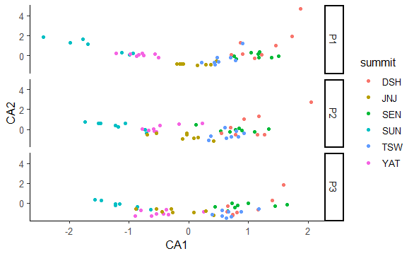

嘗試使用pca檢視植群組成

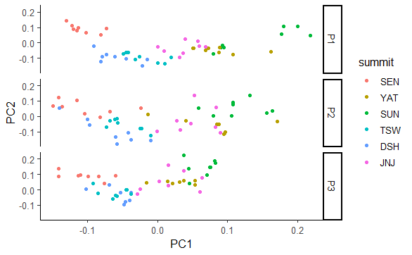

### Test 2 氣候與物種增關係

**核心概念:時間** 在氣候變化的條件下，各山峰物種的區位組成是如何變化?覆蓋增減的物種屬於何種類型? Step 1. 基礎資料載入

```r
bio_nich <- fread('Surveydata_and_niche/bio_niche.csv')
wi_nich <- fread('Surveydata_and_niche/WI_niche.csv')
name_list <- fread("Surveydata_and_niche/name_list.csv")
code_ref <- name_list[,.(code,GBIF_code)]
nich <- bio_nich[wi_nich,on=.(code=code)]
nich <- nich[code_ref,on=.(code=GBIF_code)]#將所有氣候區位資料結合
nich[,i.V1:=NULL]
setnames(x = r_sp,old =c("Target region code","Summit code","方位","Sunnit area section"),new=c("region","Summit","dir","Summit_dir"))
r_sp[,loc_code:=paste0(year,`Country code`,region,Summit,Summit_dir)]
r_sp <- r_sp[r_env,on=.(loc_code=code)]#結合環境資料中的維管束植物估值
r_sp[,T_cover:=cover*`Vascular plants`/100]#T_cover 表示相對覆蓋乘上樣區維管束植物總覆蓋度得到

r_data <- dcast(r_sp,region+Summit+dir+Summit_dir+Name+code~period,value.var = c('cover',"T_cover"),fun=sum)
```

資料說明 r_data: 統整三個時期各山峰樣區p5m_p10m的植物覆蓋相對值與絕對值 nich: 氣候區位bio_1(年均溫),bio_12(年降雨量),數字1-5為溫量指數,table中的code是GBIF下載之順序

Step 2. 結合raw data與物種niche

```r
data_frq <- r_sp[nich,on=.(code=i.code)] #計算各時期物種頻度用
input <- r_data[nich,on=.(code=i.code)]
```

Step 3. 繪製物種X氣候區位的機率密度圖 繪製溫度密度分布圖

```r
data_frq <- data_frq[!is.na(cover)]
data_frq[,Summit:=factor(Summit,levels=c("TSW","SEN","DSH","YAT","JNJ",'SUN'))]
for (i in c('DAS',"SYU")){
ggplot(data_frq[region==i],aes(x=bio_1_3/10,color=period))+
  geom_density()+
  facet_grid(Summit~dir)+
  labs(x="Average annual temperature(°C)")

ggsave(paste0('plot/temp_nichXsummitXdir_',i,'.jpeg'),width=12,height=8,dpi=600)
}
for (i in c('DAS',"SYU")){
ggplot(data_frq[region==i],aes(x=bio_12_3,color=period))+
  geom_density()+
  facet_grid(Summit~dir)+
  labs(x="Annual precipitation(mm)")+
  scale_x_discrete(limits=c("E","S","W","N"))

ggsave(paste0('plot/precip_nichXsummitXdir_',i,'.jpeg'),width=12,height=8,dpi=600)

ggplot(data_frq[region==i],aes(x=bio_1_3/10,color=period))+
  geom_density()+
  facet_grid(Summit~dir)+
  labs(x="Average annual temperature(°C)")+
  scale_x_discrete(limits=c("E","S","W","N"))

}
```

Step 4. 計算樣區的嗜熱指數與嗜濕指數

```r
data_frq[,heat:=cover*bio_1_3/10][,pre:=cover*bio_12_3]
nich_ind <- data_frq[,.(heat_ind=sum(heat)/sum(cover),pre_ind=sum(pre)/sum(cover)),by=.(region,Summit,dir,Summit_dir,period)]
for(i in c("DAS","SYU")){
ggplot(nich_ind[region==i],aes(x=dir,y=heat_ind, fill=period))+
  geom_bar(stat='identity',position=position_dodge(),width = 0.5)+
  facet_grid(Summit~.)+
  labs(x="Direction",y="Thermophilic Index")+
  scale_x_discrete(limits=c("E","S","W","N"))+
  scale_fill_brewer(palette = 'Set2')
ggsave(paste0("plot/Thermo_id_",i,".jpeg"),width = 8,height = 6,dpi=600)

ggplot(nich_ind[region==i],aes(x=dir,y=pre_ind, fill=period))+
  geom_bar(stat='identity',position=position_dodge(),width = 0.5)+
  facet_grid(Summit~.)+
  labs(x="Direction",y="Moist-philic Index")+
  scale_x_discrete(limits=c("E","S","W","N"))+
  scale_fill_brewer(palette = 'Set2')
ggsave(paste0("plot/Thermo_id_",i,".jpeg"),width = 8,height = 6,dpi=600)
}
```

Step 5. 各方位嗜熱指數與溫度差異

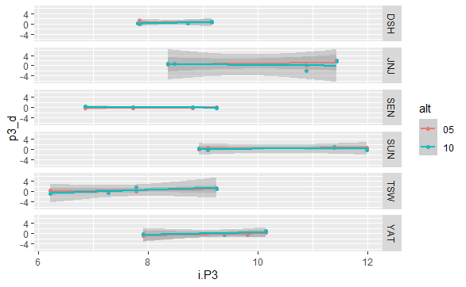